# Erythroid analysis of intron retention

# Introduction

This is a [knitr](http://yihui.name/knitr/) analysis for the paper:

- “An Erythroid Intron Retention Program Regulates Gene Expression During Terminal Erythropoiesis” by Harold Pimentel, Marilyn Parra, Sherry Gee, Narla Mohandas, Lior Pachter, John Conboy.

# Preliminaries

Let’s first load the intron required packages

```r
library("data.table")
library("reshape2")
library("tidyr")
library("dplyr")
library("RColorBrewer")
library("kma")
```

Next, let’s load the eXpress results from the annotation made by [KeepMeAround](https://github.com/pachterlab/kma):

```r
xprs_fnames <- Sys.glob('../data/xprs/ec-*/*/xprs_refGene_01.06.2015/results.xprs')

exp_names <- sub('../data/xprs/ec-jl-/','', xprs_fnames) %>%
    sub('xprs_refGene_01.06.2015/results.xprs','', .) %>%
    gsub('/', '', .) %>%
    sub('^[.a-z]+ec-jl-','', .) %>%
    gsub('proe', 'pro', .)

conds <- sub("[0-9]+", "", exp_names)
```

- `xprs_fnames` points to the eXpress output files
- `exp_names` contains the experiment names
- `conds` points to the experimental conditions

We can now read the data in using `kma` utilities:

```r
xprs <- read_express(xprs_fnames, exp_names, conds)
```

```
## Reading all eXpress data...
## Sorting...
## Extracting column:  tpm
## Extracting column:  uniq_counts
```

Let’s read in the intron to transcript table from `kma`:

```r
i2t <- read.table('../data/kma/i2t_25_final.txt', header = TRUE,
  stringsAsFactors = FALSE)
# this next line is unnecessary in newer versions of 'kma'
i2t <- dplyr::rename(i2t, "target_id" = transcript)
```

# Intron retention object

Create an intron retention object:

```r
ir <- newIntronRetention(xprs$tpm, i2t, xprs$condition, xprs$uniq_counts)
```

```
## 'melting' unique counts
## computing denominator
## computing numerator
## computing retention
## 'melting' expression
## joining unique_counts and retention data
## sorting and grouping by (intron, condition)
```

The total number of introns:

```r
nrow(ir$retention)
```

```
## [1] 186838
```

Filter analysis:

```r
ir <- ir %>%
    filter_low_tpm(1) %>%
    filter_perfect_psi(digits = 6) %>%
    filter_low_frags(3)
```

```
## Not grouped. Grouping.
```

## Zero coverage

Find the files and get metadata for them (sample namess and conditions)

```r
zc_file_names <- Sys.glob("../data/zero_coverage/ec-jl-*/*/zero_coverage_01.06.2015.txt")
zc_sample_names <- sub('../data/zero_coverage/ec-jl-', '', zc_file_names) %>%
    sub("/zero_coverage_01.06.2015.txt", "", .) %>%
    sub("/", "", .) %>%
    sub("proe", "pro", .)
zc_exp_names <- sub("[0-9]+", "", zc_sample_names)
```

Load the data using `kma`. This might take a few seconds:

```r
all_zc <- get_batch_intron_zc(zc_file_names, zc_sample_names,
    zc_exp_names)
```

[output not shown]

Now, put it in intro the `IntronRetention` object:

```r
ir <- summarize_zero_coverage(ir, all_zc)
```

```
## Summarize zero coverage across introns and conditions
## Join IntronRetention and zero coverage
```

# Hypothesis testing

First, compute the test.

```r
set.seed(42)
ret_test <- retention_test(ir)
```

```
## aggregating filters
## joining filtered data set
## estimating the null for each condition
## computing p-values
```

Do some reordering to get things appearing nicely on plots:

```r
ret_test <- ret_test %>%
    mutate(condition = factor(condition, c("pro", "ebaso", "lbaso", "poly", "ortho"))) %>%
    arrange(intron, condition)
```

Munge things a little bit to get nice tables

```r
ir$flat <- ir$flat %>%
    mutate(condition = factor(condition, c("pro", "ebaso", "lbaso", "poly", "ortho"))) %>%
    arrange(dplyr::desc(intron), condition)

flat_w_pval <- data.table(ir$flat) %>%
    left_join(data.table(ret_test), by = c("intron", "condition")) %>%
    arrange(dplyr::desc(intron), condition)
flat_w_pval <- flat_w_pval %>%
    add_gene_names(ir)
ret_test_gene <- add_gene_names(ret_test, ir)
```

Normally, the `ret_test` only returns things that pass filters in that particular condition. We are going to munge things a bit to get IR values for *everything*, but put a `NA` in the `pvalue` column:

```r
flat_up <- flat_w_pval %>%
    group_by(intron, condition) %>%
    mutate(mean_retention = replace(mean_retention,
            is.na(mean_retention), mean(retention)),
        var_retention = replace(var_retention,
            is.na(var_retention), var(retention)))
```

`flat_up` contains information for *everything* (including filters). We can summarize things a bit:

```r
flat_no_filt <- as.data.frame(flat_up, stringsAsFactors = FALSE) %>% select(intron, condition, mean_retention,
    var_retention, pvalue, qvalue, gene, intron_extension, -starts_with("f_")) %>%
    distinct() %>%
    arrange(intron_extension, condition)
```

`flat_no_filt` is now the table reported in the supplement `flat_summarize.csv`

# Clustering

## Preparing the data

First, we need to get the data intro a matrix that the `R` clustering tools like:

```r
s_ret_test <- ret_test %>%
  select(intron, condition, mean_retention) %>%
  spread(condition, mean_retention)
s_ret_test <- s_ret_test[complete.cases(s_ret_test),]
```

The previous chunk gets the mean retention of the intron and extracts only introns that pass all filters in all conditions. Let’s munge some more to get an actual matrix

```r
s_all_filt <- as.data.frame(s_ret_test)
rownames(s_all_filt) <- s_ret_test$intron
s_all_filt$intron <- NULL
s_all_filt <- as.matrix(s_all_filt)
head(s_all_filt)
```

```
##                                  pro       ebaso       lbaso        poly
## chr1:100195304-100203641 0.012520587 0.025086042 0.024861422 0.034993193
## chr1:100503872-100515464 0.000831949 0.001532952 0.001165858 0.001959045
## chr1:100535241-100542720 0.006912084 0.008984437 0.010204041 0.012746000
## chr1:100609699-100613449 0.136110524 0.159571713 0.154412496 0.155413092
## chr1:100752759-100756958 0.040320919 0.057726780 0.053297819 0.048928038
## chr1:10093752-10132085   0.001424394 0.001840939 0.001892875 0.004454957
##                                ortho
## chr1:100195304-100203641 0.028816271
## chr1:100503872-100515464 0.003476275
## chr1:100535241-100542720 0.009555033
## chr1:100609699-100613449 0.176750507
## chr1:100752759-100756958 0.059240034
## chr1:10093752-10132085   0.003353131
```

## Performing the clustering

```r
set.seed(42)
s_all_filt_km <- kmeans(s_all_filt, centers = 9, iter.max = 1000, nstart = 100)
```

## Visualization

Let’s put the clustering results into a form `ggplot` likes:

```r
melt_clust <- function(data, clust) {
  stopifnot(is(clust, "kmeans"))
  stopifnot(is(data, "matrix"))

  m_data <- melt(data, varnames = c("intron", "condition"),
    value.name = "mean_retention")
  clust_names <- data.frame(intron = names(clust$cluster),
    cluster = clust$cluster)
  m_data <- left_join(data.table(m_data), data.table(clust_names), by = "intron")

  clust_sizes <- data.frame(cluster = 1:length(clust$size), size = clust$size)
  clust_data <- left_join(data.table(m_data), data.table(clust_sizes),
    by = "cluster")

  clust_data
}
```

```r
m_km <- melt_clust(s_all_filt, s_all_filt_km)
# append the gene names
i2g <- i2t %>%
    select(intron, gene) %>%
    distinct()
m_km <- left_join(m_km, data.table(i2g), by = c("intron"))
```

The stuff below is simply to make the plot pretty and in the ordering we want:

```r
size_order <- as.character(c(124, 346, 33,
        116, 178, 426,
        1002, 2484, 5443))
size_order_cname <- paste0(paste0("C", 1:length(size_order), " ("), size_order, ")")
size_mapping <- data.frame(size_reorder = size_order, size_name = size_order_cname,
  stringsAsFactors = FALSE)
m_km <- m_km %>%
  mutate(size_reorder = factor(as.character(size), levels = size_order))
m_km <- data.table(m_km) %>%
  mutate(size_reorder = as.character(size_reorder)) %>%
  inner_join(data.table(size_mapping), by = c("size_reorder")) %>%
  as.data.frame(stringsAsFactors = FALSE)
m_km <- m_km %>%
  mutate(size_name = factor(as.character(size_name), levels = size_order_cname))
m_mean_km <- m_km %>%
  group_by(condition, cluster, size_name) %>%
  summarise(condition_mean = mean(mean_retention)) %>%
  mutate(intron = NA)
get_palette <- colorRampPalette(brewer.pal(5, "Set2"))
colour_count <- length(unique(m_km$intron))
```

This is the clustering figure that appears in the paper:

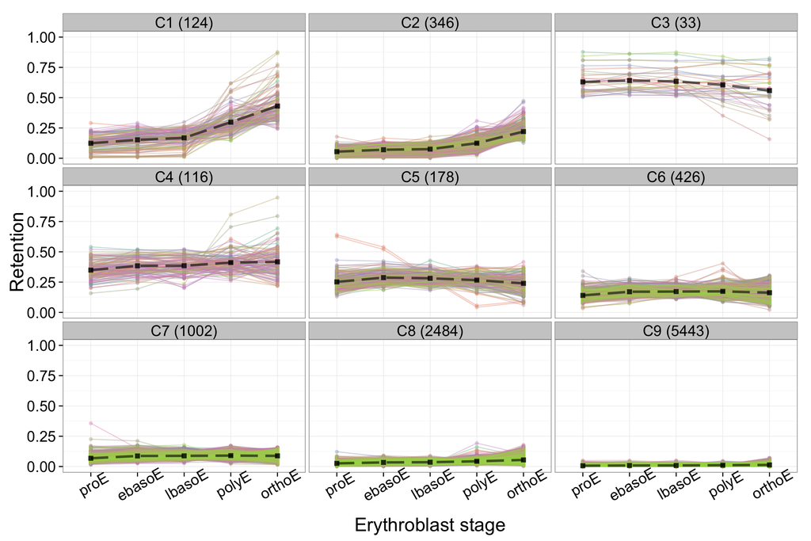

```r
ggplot(m_km,
    aes(condition, mean_retention, group = intron, colour = intron)) +
    geom_point(alpha = 0.4) +
    geom_line(alpha = 0.4) +
    theme_bw(20) +
    theme(legend.position = "none") +
    xlab("Erythroblast stage") +
    ylab("Retention") +
    ylim(0, 1) +
    scale_colour_manual(values = get_palette(colour_count)) +
    geom_point(mapping = aes(condition, condition_mean),
        data = m_mean_km,
        colour = "black", alpha = 0.8, shape = 15, size = 2.5) +
    geom_line(mapping = aes(condition, condition_mean),
        data = m_mean_km,
        colour = "black", alpha = 0.6, size = 1.25, linetype = "longdash") +
    facet_wrap( ~ size_name) +
    scale_x_discrete(labels = c("proE", "ebasoE", "lbasoE", "polyE", "orthoE")) +
    theme(axis.text.x = element_text(angle = 30))
```

# Distribution of retention

Compute the ECDF per condition based on the mean retention

```r
ret_dist <- ret_test %>%
  group_by(condition) %>%
  do({
    ret <- data.frame(retention_level = seq(0, 1, length.out = 1000)) %>%
    mutate(cdf = ecdf(.$mean_retention)(retention_level),
      count = ceiling(cdf * nrow(.)),
      inv_cdf = 1 - cdf,
      inv_count = nrow(.) - count)
    ret
  })
```

Load a color blind palette

```r
cbbPalette <- c("#E69F00", "#56B4E9", "#009E73", "#F0E442", "#0072B2",
  "#D55E00", "#CC79A7", "#000000")
```

Make the plot that appears in the supplement:

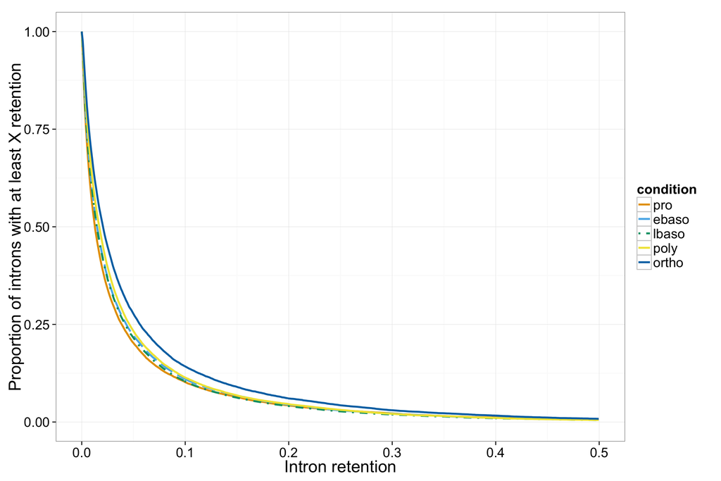

```r
ggplot(ret_dist, aes(retention_level, inv_cdf, group = condition,
    colour = condition)) +
    geom_line(aes(linetype = condition), size = 1.10) +
    scale_color_manual(values = cbbPalette) +
    scale_linetype_manual(
      values = c("solid", "longdash", "dotdash", "solid", "solid")) +
    theme_bw(20) +
    ylab("Proportion of introns with at least X retention") +
    xlab("Intron retention") +
    xlim(0, 0.50)
```